# dacc-preProcess-t1-spring.R

ana

Wed Oct 11 13:01:00 2017

Para entrenar se utilizaron sólo los meses de agosto, setiembre, octubre, noviembre y se desfasaron los datos a un día, es decir, contamos sólo con variables del día anterior para predecir la temperatura mínima / helada del día siguiente.

### Preprocesando el dataset

```r
source("bnlearn-utils.R")
source("dataset-processing.R")
set.seed(147)
```

datos de los meses agosto, setiembre, octubre y noviembre

```r
sensores <- dacc.spring()
```

Variables del dataset

```r
colnames(sensores)
```

```
##  [1] "las_paredes.Hmin" "las_paredes.Hmed" "las_paredes.Hmax"
##  [4] "las_paredes.Tmin" "las_paredes.Tmax" "las_paredes.Tmed"
##  [7] "la_llave.Hmin"    "la_llave.Hmed"    "la_llave.Hmax"
## [10] "la_llave.Tmin"    "la_llave.Tmax"    "la_llave.Tmed"
## [13] "tunuyan.Hmin"     "tunuyan.Hmed"     "tunuyan.Hmax"
## [16] "tunuyan.Tmin"     "tunuyan.Tmax"     "tunuyan.Tmed"
## [19] "junin.Tmax"       "junin.Tmed"       "junin.Tmin"
## [22] "junin.Hmax"       "junin.Hmed"       "junin.Hmin"
## [25] "agua_amarga.Tmax" "agua_amarga.Tmed" "agua_amarga.Tmin"
## [28] "agua_amarga.Hmax" "agua_amarga.Hmed" "agua_amarga.Hmin"
## [31] "el_marcado.Tmax"  "el_marcado.Tmed"  "el_marcado.Tmin"
## [34] "el_marcado.Hmax"  "el_marcado.Hmed"  "el_marcado.Hmin"
```

Una vista breve

```r
head(sensores)
```

```
##                     las_paredes.Hmin las_paredes.Hmed las_paredes.Hmax
## 2007-08-21 03:00:00         24.75000         27.04167         29.33333
## 2007-08-22 03:00:00         25.00000         26.54167         28.58333
## 2007-08-23 03:00:00         21.79167         24.37500         27.25000
## 2007-08-24 03:00:00         42.16667         44.04167         46.16667
## 2007-08-25 03:00:00         41.08333         43.70833         46.66667
## 2007-08-26 03:00:00         23.79167         26.95833         29.79167
##                     las_paredes.Tmin las_paredes.Tmax las_paredes.Tmed
## 2007-08-21 03:00:00         4.555417         6.642500         5.541667
## 2007-08-22 03:00:00         7.095833         8.844583         7.870833
## 2007-08-23 03:00:00         7.865833         9.756250         8.783333
## 2007-08-24 03:00:00         2.748333         3.456250         3.050000
## 2007-08-25 03:00:00         2.643750         4.040833         3.300000
## 2007-08-26 03:00:00         3.678333         5.719583         4.583333
##                     la_llave.Hmin la_llave.Hmed la_llave.Hmax
## 2007-08-21 03:00:00      14.46154      17.46154      20.38462
## 2007-08-22 03:00:00      28.62500      31.50000      34.75000
## 2007-08-23 03:00:00      26.45833      29.00000      31.45833
## 2007-08-24 03:00:00      37.20833      39.41667      41.54167
## 2007-08-25 03:00:00      39.75000      43.41667      46.16667
## 2007-08-26 03:00:00      28.00000      30.83333      33.83333
##                     la_llave.Tmin la_llave.Tmax la_llave.Tmed tunuyan.Hmin
## 2007-08-21 03:00:00     11.198462     13.785385     12.369231     56.16667
## 2007-08-22 03:00:00      7.492917      9.972083      8.745833     58.50000
## 2007-08-23 03:00:00      7.777083      9.885417      8.775000     55.58333
## 2007-08-24 03:00:00      4.284583      4.899167      4.529167     69.16667
## 2007-08-25 03:00:00      3.956667      5.420000      4.550000     59.29167
## 2007-08-26 03:00:00      4.425417      6.629583      5.470833     52.95833
##                     tunuyan.Hmed tunuyan.Hmax tunuyan.Tmin tunuyan.Tmax
## 2007-08-21 03:00:00     59.62500     62.79167     4.432917     6.753750
## 2007-08-22 03:00:00     61.29167     64.66667     4.723750     6.852083
## 2007-08-23 03:00:00     58.29167     61.00000     6.486667     8.593750
## 2007-08-24 03:00:00     70.62500     72.41667     3.330000     4.064167
## 2007-08-25 03:00:00     62.41667     66.04167     3.541667     4.773750
## 2007-08-26 03:00:00     56.58333     60.29167     1.103333     3.282083
##                     tunuyan.Tmed junin.Tmax junin.Tmed junin.Tmin
## 2007-08-21 03:00:00     5.487500       18.6        7.1       -1.3
## 2007-08-22 03:00:00     5.687500       19.1        9.0        0.9
## 2007-08-23 03:00:00     7.475000       19.5       10.6        3.9
## 2007-08-24 03:00:00     3.629167       11.2        5.8        3.1
```

[output cut: 22 more lines]

```
## 2007-08-26 03:00:00               67               50            13.9
##                     el_marcado.Tmed el_marcado.Tmin el_marcado.Hmax
## 2007-08-21 03:00:00             7.4            -4.4              76
## 2007-08-22 03:00:00             8.2            -3.2              74
## 2007-08-23 03:00:00             9.6            -0.2              67
## 2007-08-24 03:00:00             5.7             3.3              66
## 2007-08-25 03:00:00             4.5            -0.2              72
## 2007-08-26 03:00:00             3.9            -4.6              74
##                     el_marcado.Hmed el_marcado.Hmin
## 2007-08-21 03:00:00              44              18
## 2007-08-22 03:00:00              45              15
## 2007-08-23 03:00:00              40              15
## 2007-08-24 03:00:00              53              31
## 2007-08-25 03:00:00              57              29
## 2007-08-26 03:00:00              46              19
```

Cantidad de filas y columnas

```r
cat("Rows: ",nrow(sensores)," Columns: ",ncol(sensores))
```

```
## Rows:  546  Columns:  36
```

como denomino a las variables que quiero predecir

```r
pred_sensores = colnames(sensores)[c(4,10,16,21,27)]

# "las_paredes.Tmin" "la_llave.Tmin"    "tunuyan.Tmin"     "junin.Tmin"       "agua_amarga.Tmin"

pred_sensores
```

```
## [1] "las_paredes.Tmin" "la_llave.Tmin"    "tunuyan.Tmin"
## [4] "junin.Tmin"       "agua_amarga.Tmin"
```

Obtengo dataset con variables desfasadas a un dia

```r
aux <- desfasar.dataset.t1(sensores, pred_sensores)
pred_sensores <- aux$vars
df <- aux$data
```

nombres de las variables a usar para entrenar/testear

```r
colnames(df)
```

```
##  [1] "las_paredes.Hmin_T_1" "las_paredes.Hmed_T_1" "las_paredes.Hmax_T_1"
##  [4] "las_paredes.Tmin_T_1" "las_paredes.Tmax_T_1" "las_paredes.Tmed_T_1"
##  [7] "la_llave.Hmin_T_1"    "la_llave.Hmed_T_1"    "la_llave.Hmax_T_1"
## [10] "la_llave.Tmin_T_1"    "la_llave.Tmax_T_1"    "la_llave.Tmed_T_1"
## [13] "tunuyan.Hmin_T_1"     "tunuyan.Hmed_T_1"     "tunuyan.Hmax_T_1"
## [16] "tunuyan.Tmin_T_1"     "tunuyan.Tmax_T_1"     "tunuyan.Tmed_T_1"
## [19] "junin.Tmax_T_1"       "junin.Tmed_T_1"       "junin.Tmin_T_1"
## [22] "junin.Hmax_T_1"       "junin.Hmed_T_1"       "junin.Hmin_T_1"
## [25] "agua_amarga.Tmax_T_1" "agua_amarga.Tmed_T_1" "agua_amarga.Tmin_T_1"
## [28] "agua_amarga.Hmax_T_1" "agua_amarga.Hmed_T_1" "agua_amarga.Hmin_T_1"
## [31] "el_marcado.Tmax_T_1"  "el_marcado.Tmed_T_1"  "el_marcado.Tmin_T_1"
## [34] "el_marcado.Hmax_T_1"  "el_marcado.Hmed_T_1"  "el_marcado.Hmin_T_1"
## [37] "las_paredes.Tmin_t"   "la_llave.Tmin_t"      "tunuyan.Tmin_t"
## [40] "junin.Tmin_t"         "agua_amarga.Tmin_t"
```

nro de ejemplos

```r
nrow(df)
```

```
## [1] 545
```

nro de variables

```r
ncol(df)
```

```
## [1] 41
```

black list de aristas

```r
bl <- get_blacklist(pred_sensores)
```

```
## 'data.frame':    0 obs. of  2 variables:
##  $ from: atomic
##   ..- attr(*, "levels")= chr  "las_paredes.Tmin_t" "la_llave.Tmin_t" "tunuyan.Tmin_t" "junin.Tmin_t" ...
##  $ to  : atomic
##   ..- attr(*, "levels")= chr  "las_paredes.Tmin_t" "la_llave.Tmin_t" "tunuyan.Tmin_t" "junin.Tmin_t" ...
```

```r
wl <- get_whitelist(pred_sensores,colnames(df))
```

```
## 'data.frame':    0 obs. of  2 variables:
##  $ from: chr
##  $ to  : chr
```

### Training set y test dataset

```r
df[,1:ncol(df)] <- lapply(df[,1:ncol(df)],as.numeric) # <- convertir a numeric
until <- round(nrow(df)*.67)
training.set = df[1:until-1, ] # This is training set to learn the parameters
test.set = df[until:nrow(df), ]
until
```

```
## [1] 365
```

Librería para aprendizaje de redes bayesianas

```r
library(bnlearn)
```

Aprendemos una red bayesiana usando el algoritmo hc y pasando como restricciones las white y black lists

```r
start_time <- Sys.time()
res = hc(training.set, whitelist=wl,blacklist = bl)
end_time <- Sys.time()
end_time - start_time
```

```
## Time difference of 0.9742336 secs
```

Aprendizaje de parametros

```r
start_time <- Sys.time()
fitted = bn.fit(res, training.set)     # learning of parameters
end_time <- Sys.time()
end_time - start_time
```

```
## Time difference of 0.02827287 secs
```

guardo modelo para más análisis o corridas posteriores

```r
save(res, file = paste("hc-dacc-spring-t1-",Sys.time(),".RData",sep=""))
```

Mostramos los parámetros para los nodos que nos interesan predecir

```r
fitted[pred_sensores]
```

```
## $las_paredes.Tmin_t
##
##   Parameters of node las_paredes.Tmin_t (Gaussian distribution)
##
## Conditional density: las_paredes.Tmin_t | las_paredes.Hmin_T_1 + las_paredes.Hmed_T_1 + las_paredes.Hmax_T_1 + las_paredes.Tmin_T_1 + las_paredes.Tmax_T_1 + las_paredes.Tmed_T_1 + la_llave.Tmed_T_1 + junin.Hmax_T_1 + el_marcado.Tmax_T_1
## Coefficients:
##          (Intercept)  las_paredes.Hmin_T_1  las_paredes.Hmed_T_1
##          -4.67284911           -0.08272404            0.51781581
## las_paredes.Hmax_T_1  las_paredes.Tmin_T_1  las_paredes.Tmax_T_1
##          -0.44165071           -0.41165020           -0.47652732
## las_paredes.Tmed_T_1     la_llave.Tmed_T_1        junin.Hmax_T_1
##           0.98159100            0.47248295            0.04136385
##  el_marcado.Tmax_T_1
##           0.30378055
## Standard deviation of the residuals: 3.43888
##
## $la_llave.Tmin_t
##
##   Parameters of node la_llave.Tmin_t (Gaussian distribution)
##
## Conditional density: la_llave.Tmin_t | la_llave.Hmin_T_1 + la_llave.Hmed_T_1 + la_llave.Hmax_T_1 + la_llave.Tmin_T_1 + la_llave.Tmax_T_1 + la_llave.Tmed_T_1 + el_marcado.Tmax_T_1
## Coefficients:
##         (Intercept)    la_llave.Hmin_T_1    la_llave.Hmed_T_1
##          -0.1091950            0.7075018           -1.7636574
##   la_llave.Hmax_T_1    la_llave.Tmin_T_1    la_llave.Tmax_T_1
##           1.0482094           -2.7658569           -5.1742846
##   la_llave.Tmed_T_1  el_marcado.Tmax_T_1
##           8.4542607            0.3625240
## Standard deviation of the residuals: 3.267084
##
## $tunuyan.Tmin_t
##
##   Parameters of node tunuyan.Tmin_t (Gaussian distribution)
##
## Conditional density: tunuyan.Tmin_t | tunuyan.Hmin_T_1 + tunuyan.Hmed_T_1 + tunuyan.Hmax_T_1 + tunuyan.Tmin_T_1 + tunuyan.Tmax_T_1 + tunuyan.Tmed_T_1 + agua_amarga.Tmax_T_1 + el_marcado.Tmax_T_1
## Coefficients:
##          (Intercept)      tunuyan.Hmin_T_1      tunuyan.Hmed_T_1
##           -6.3869972             0.1941078            -1.1967979
##     tunuyan.Hmax_T_1      tunuyan.Tmin_T_1      tunuyan.Tmax_T_1
##            1.0593557             0.8923074            -1.5468017
```

[output cut: 18 more lines]

```
## $agua_amarga.Tmin_t
##
##   Parameters of node agua_amarga.Tmin_t (Gaussian distribution)
##
## Conditional density: agua_amarga.Tmin_t | las_paredes.Hmin_T_1 + la_llave.Tmin_T_1 + junin.Hmax_T_1 + agua_amarga.Tmax_T_1 + agua_amarga.Tmed_T_1 + agua_amarga.Tmin_T_1 + agua_amarga.Hmax_T_1 + agua_amarga.Hmed_T_1 + agua_amarga.Hmin_T_1 + el_marcado.Tmed_T_1
## Coefficients:
##          (Intercept)  las_paredes.Hmin_T_1     la_llave.Tmin_T_1
##         -11.91091455            0.05755845            0.21039627
##       junin.Hmax_T_1  agua_amarga.Tmax_T_1  agua_amarga.Tmed_T_1
##           0.03842439            0.14712097            0.28375982
## agua_amarga.Tmin_T_1  agua_amarga.Hmax_T_1  agua_amarga.Hmed_T_1
##          -0.17570584           -0.10219770            0.10582094
## agua_amarga.Hmin_T_1   el_marcado.Tmed_T_1
##           0.02709383            0.34488763
## Standard deviation of the residuals: 2.622928
```

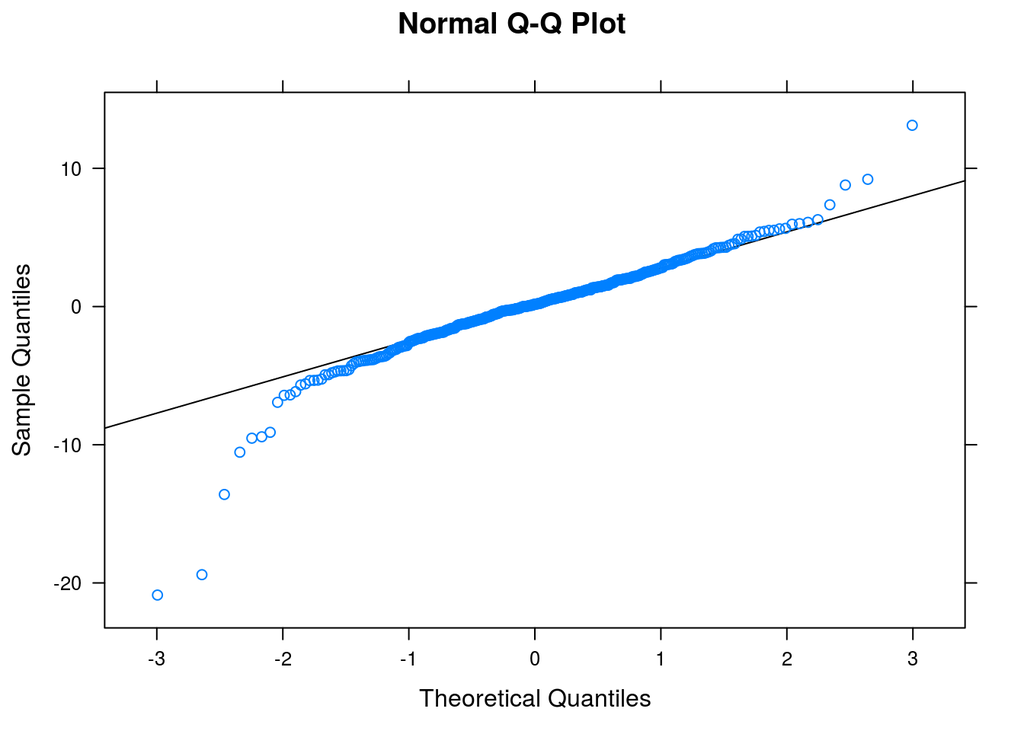

```r
bn.fit.qqplot(fitted$las_paredes.Tmin_t)
```

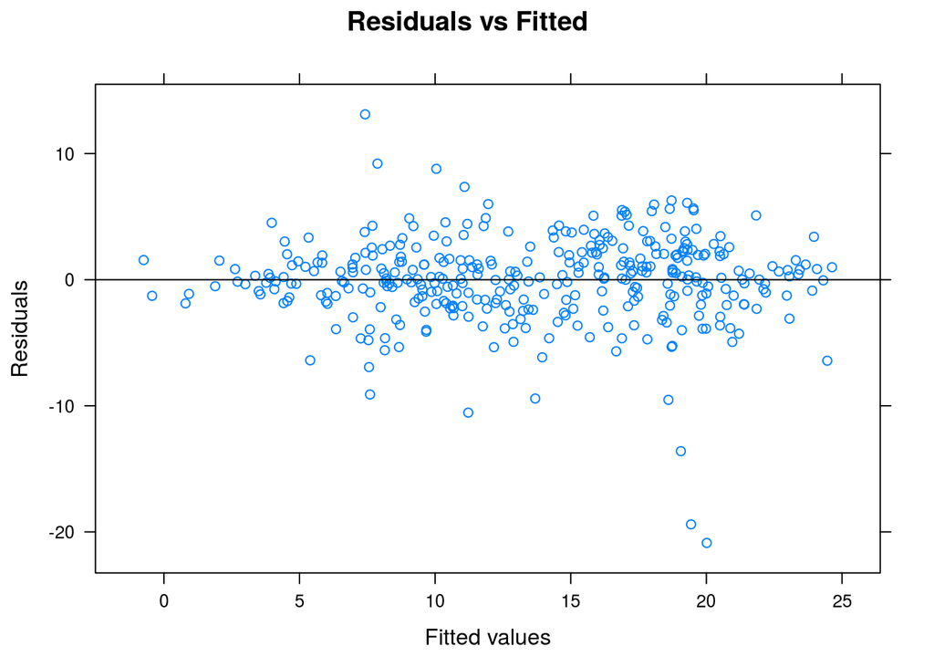

```r
bn.fit.xyplot(fitted$las_paredes.Tmin_t)
```

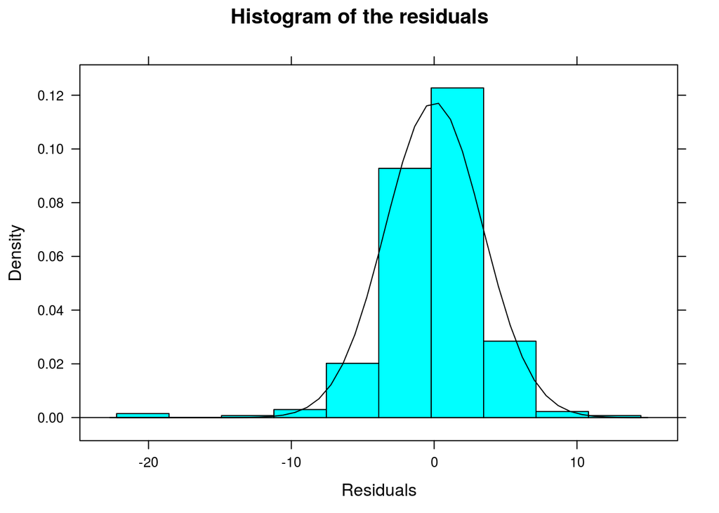

```r
bn.fit.histogram(fitted$las_paredes.Tmin_t)
```

Markov blanket de las variables de interés para predecir

```r
for(i in 1:length(pred_sensores))
{
  cat("Markov blanket of ",pred_sensores[i],"\n")
  print(mb(res,pred_sensores[i]))
}
```

```
## Markov blanket of  las_paredes.Tmin_t
##  [1] "las_paredes.Hmin_T_1" "las_paredes.Hmed_T_1" "las_paredes.Hmax_T_1"
##  [4] "las_paredes.Tmin_T_1" "las_paredes.Tmax_T_1" "las_paredes.Tmed_T_1"
##  [7] "la_llave.Tmed_T_1"    "tunuyan.Hmin_T_1"     "tunuyan.Tmin_T_1"
## [10] "tunuyan.Tmax_T_1"     "junin.Tmax_T_1"       "junin.Tmed_T_1"
## [13] "junin.Tmin_T_1"       "junin.Hmax_T_1"       "junin.Hmed_T_1"
## [16] "agua_amarga.Tmed_T_1" "agua_amarga.Hmed_T_1" "agua_amarga.Hmin_T_1"
## [19] "el_marcado.Tmax_T_1"  "el_marcado.Tmed_T_1"  "el_marcado.Tmin_T_1"
## [22] "el_marcado.Hmax_T_1"  "el_marcado.Hmed_T_1"  "el_marcado.Hmin_T_1"
## Markov blanket of  la_llave.Tmin_t
##  [1] "la_llave.Hmin_T_1"    "la_llave.Hmed_T_1"    "la_llave.Hmax_T_1"
##  [4] "la_llave.Tmin_T_1"    "la_llave.Tmax_T_1"    "la_llave.Tmed_T_1"
##  [7] "tunuyan.Hmin_T_1"     "tunuyan.Hmed_T_1"     "tunuyan.Hmax_T_1"
## [10] "tunuyan.Tmin_T_1"     "tunuyan.Tmax_T_1"     "junin.Tmin_T_1"
## [13] "junin.Hmax_T_1"       "junin.Hmin_T_1"       "agua_amarga.Tmax_T_1"
## [16] "agua_amarga.Tmin_T_1" "agua_amarga.Hmed_T_1" "el_marcado.Tmax_T_1"
## Markov blanket of  tunuyan.Tmin_t
## [1] "tunuyan.Hmin_T_1"     "tunuyan.Hmed_T_1"     "tunuyan.Hmax_T_1"
## [4] "tunuyan.Tmin_T_1"     "tunuyan.Tmax_T_1"     "tunuyan.Tmed_T_1"
## [7] "agua_amarga.Tmax_T_1" "el_marcado.Tmax_T_1"
## Markov blanket of  junin.Tmin_t
## [1] "tunuyan.Hmed_T_1" "tunuyan.Hmax_T_1" "junin.Tmax_T_1"
## [4] "junin.Tmed_T_1"   "junin.Tmin_T_1"   "junin.Hmax_T_1"
## [7] "junin.Hmed_T_1"   "junin.Hmin_T_1"
## Markov blanket of  agua_amarga.Tmin_t
##  [1] "las_paredes.Hmin_T_1" "la_llave.Tmin_T_1"    "junin.Hmax_T_1"
##  [4] "agua_amarga.Tmax_T_1" "agua_amarga.Tmed_T_1" "agua_amarga.Tmin_T_1"
##  [7] "agua_amarga.Hmax_T_1" "agua_amarga.Hmed_T_1" "agua_amarga.Hmin_T_1"
## [10] "el_marcado.Tmed_T_1"
```

Predicciones, evaluación en conjunto de testeo

```r
df_res <- errors_regression(pred_sensores, fitted, test.set, verbose = FALSE)
```

```
## Testing on  las_paredes.Tmin_t
## Testing on  la_llave.Tmin_t
## Testing on  tunuyan.Tmin_t
## Testing on  junin.Tmin_t
## Testing on  agua_amarga.Tmin_t
```

```r
df_res
```

```
##             Variable                  ME             RMSE              MAE
## 1 las_paredes.Tmin_t   0.387258503028571 3.91733700317721 2.84768945293871
## 2    la_llave.Tmin_t   0.536765673921369 3.70939347172685 2.75077800780682
## 3     tunuyan.Tmin_t   0.144508822953913 3.17103078999028 2.24178374635245
## 4       junin.Tmin_t -0.0845217933532734 2.84638399162295 2.01069193301371
## 5 agua_amarga.Tmin_t   0.495149229241086 2.92539243510072 2.18391979567764
##                 MPE             MAPE
## 1 -1.82031937323771 35.7828266436308
## 2 -61.6106599451895  78.835949662908
## 3 -7.01167389905192 29.8455113041043
## 4  14.6218134690989  80.631432961252
## 5  10.5782947396702 72.0647014497133
```

plots de R squared

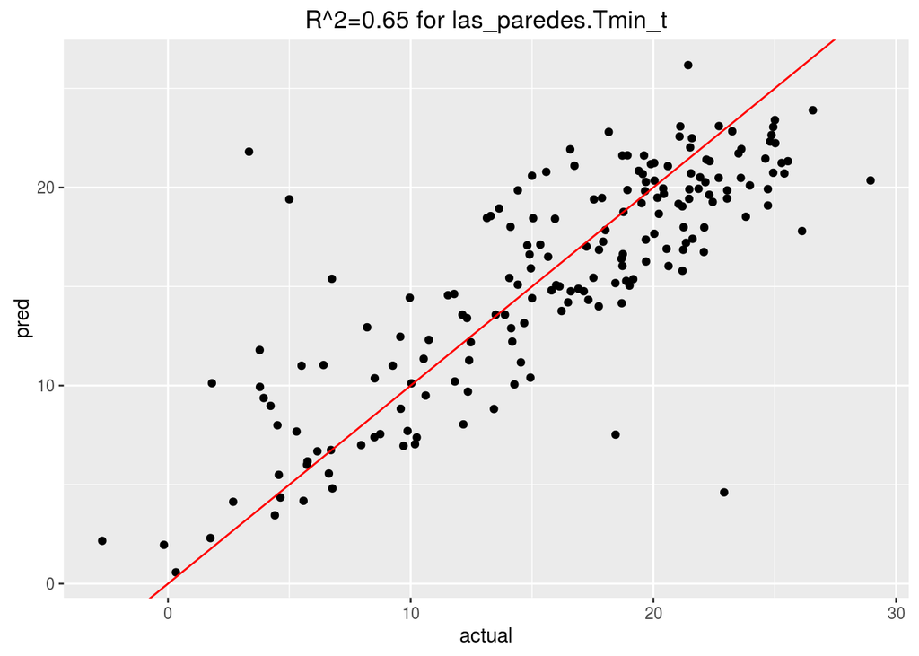

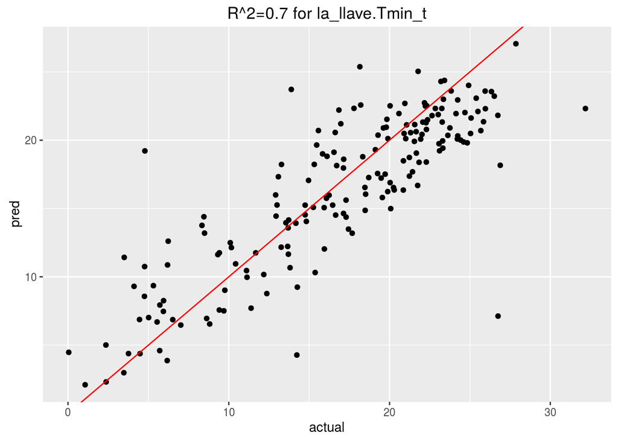

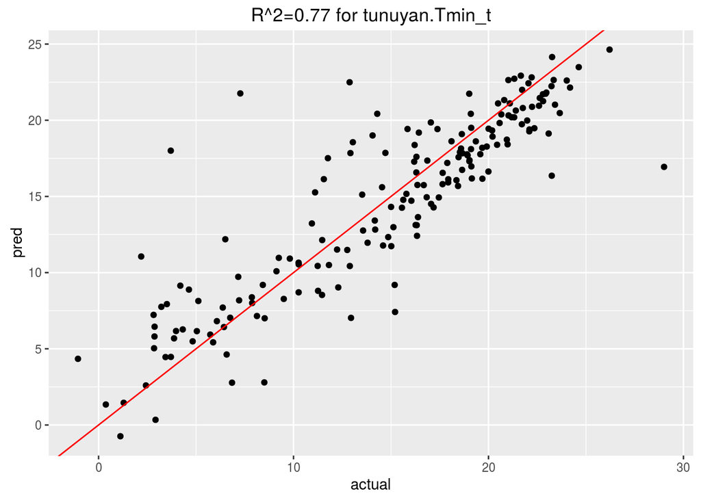

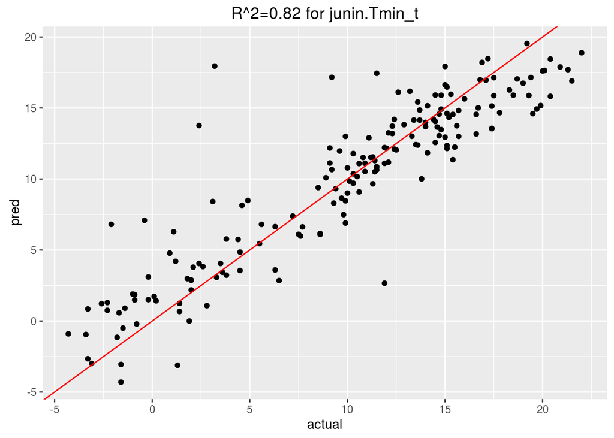

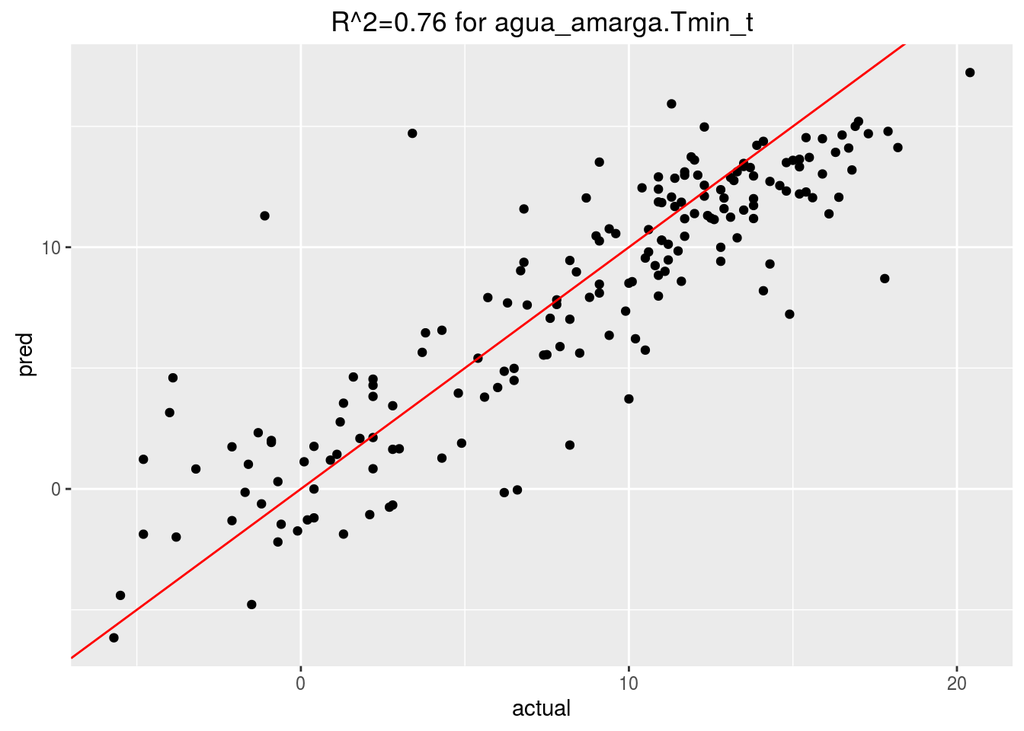

```r
r2_plots_inline(pred_sensores, fitted, test.set)
```

llamar confusionMatrix de caret, pasar primero “a factor of predicted classes, then a factor of classes to be used as the true results

```r
breaks.binario <- c(-10,0,50) # caso Helada y no helada
my.breaks <- c(-10,-5,0,2,5,10,50)
```

### Caso binario: helada o no helada

```r
conf_matrix_binario = conf_matrix(fitted,pred_sensores,test.set, breaks.binario)
```

```
## Variable  las_paredes.Tmin_t
## Confusion Matrix and Statistics
##
##           Reference
## Prediction (-10,0] (0,50]
##    (-10,0]       0      0
##    (0,50]        2    179
##
##                Accuracy : 0.989
##                  95% CI : (0.9607, 0.9987)
##     No Information Rate : 0.989
##     P-Value [Acc > NIR] : 0.6767
##
##                   Kappa : 0
##  Mcnemar's Test P-Value : 0.4795
##
##             Sensitivity : 0.00000
##             Specificity : 1.00000
##          Pos Pred Value :     NaN
##          Neg Pred Value : 0.98895
##              Prevalence : 0.01105
##          Detection Rate : 0.00000
##    Detection Prevalence : 0.00000
##       Balanced Accuracy : 0.50000
##
##        'Positive' Class : (-10,0]
##
## Variable  la_llave.Tmin_t
## Confusion Matrix and Statistics
##
##           Reference
## Prediction (-10,0] (0,50]
##    (-10,0]       0      0
##    (0,50]        0    181
##
##                Accuracy : 1
##                  95% CI : (0.9798, 1)
##     No Information Rate : 1
##     P-Value [Acc > NIR] : 1
##
```

[output cut: 80 more lines]

```
##
##                   Kappa : 0.4615
##  Mcnemar's Test P-Value : 0.8231
##
##             Sensitivity : 0.50000
##             Specificity : 0.94340
##          Pos Pred Value : 0.55000
##          Neg Pred Value : 0.93168
##              Prevalence : 0.12155
##          Detection Rate : 0.06077
##    Detection Prevalence : 0.11050
##       Balanced Accuracy : 0.72170
##
##        'Positive' Class : (-10,0]
##
```

### Evaluación de predicción en rangos de temperaturas

```r
conf_matrix_temp = conf_matrix(fitted,pred_sensores,test.set, my.breaks)
```

```
## Variable  las_paredes.Tmin_t
## Confusion Matrix and Statistics
##
##           Reference
## Prediction (-10,-5] (-5,0] (0,2] (2,5] (5,10] (10,50]
##   (-10,-5]        0      0     0     0      0       0
##   (-5,0]          0      0     0     0      0       0
##   (0,2]           0      1     1     0      0       0
##   (2,5]           0      1     1     3      2       1
##   (5,10]          0      0     0     5     12       7
##   (10,50]         0      0     1     3      8     135
##
## Overall Statistics
##
##                Accuracy : 0.8343
##                  95% CI : (0.7719, 0.8853)
##     No Information Rate : 0.7901
##     P-Value [Acc > NIR] : 0.08279
##
##                   Kappa : 0.5116
##  Mcnemar's Test P-Value : NA
##
## Statistics by Class:
##
##                      Class: (-10,-5] Class: (-5,0] Class: (0,2]
## Sensitivity                       NA       0.00000     0.333333
## Specificity                        1       1.00000     0.994382
## Pos Pred Value                    NA           NaN     0.500000
## Neg Pred Value                    NA       0.98895     0.988827
## Prevalence                         0       0.01105     0.016575
## Detection Rate                     0       0.00000     0.005525
## Detection Prevalence               0       0.00000     0.011050
## Balanced Accuracy                 NA       0.50000     0.663858
##                      Class: (2,5] Class: (5,10] Class: (10,50]
## Sensitivity               0.27273        0.5455         0.9441
## Specificity               0.97059        0.9245         0.6842
## Pos Pred Value            0.37500        0.5000         0.9184
## Neg Pred Value            0.95376        0.9363         0.7647
## Prevalence                0.06077        0.1215         0.7901
## Detection Rate            0.01657        0.0663         0.7459
```

[output cut: 155 more lines]

```
## Pos Pred Value              1.000000       0.47368       0.2500
## Neg Pred Value              0.994444       0.93210       0.9515
## Prevalence                  0.011050       0.11050       0.0663
## Detection Rate              0.005525       0.04972       0.0221
## Detection Prevalence        0.005525       0.10497       0.0884
## Balanced Accuracy           0.750000       0.69394       0.6312
##                      Class: (2,5] Class: (5,10] Class: (10,50]
## Sensitivity               0.33333        0.5789         0.8022
## Specificity               0.91411        0.8531         0.9000
## Pos Pred Value            0.30000        0.5116         0.8902
## Neg Pred Value            0.92547        0.8841         0.8182
## Prevalence                0.09945        0.2099         0.5028
## Detection Rate            0.03315        0.1215         0.4033
## Detection Prevalence      0.11050        0.2376         0.4530
## Balanced Accuracy         0.62372        0.7160         0.8511
```

Test de predicción con randomForest

```r
library(randomForest)
```

```
## Variable  las_paredes.Tmin_t  MSE: 16.00234  Rsquared:  0.6371349
```

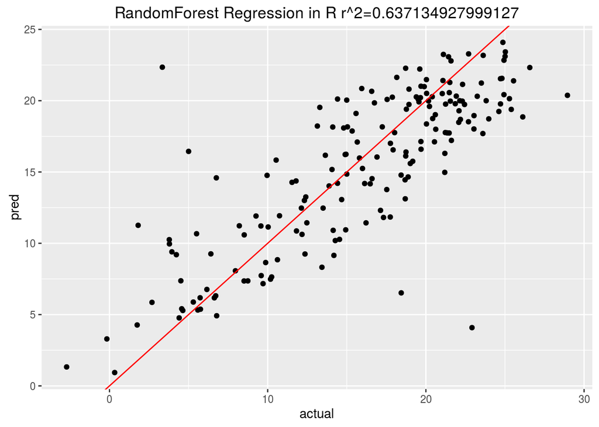

```
## Confusion matrix helada/no helada la_llave.Tmin_t
## Confusion Matrix and Statistics
##
##           Reference
## Prediction (-10,0] (0,50]
##    (-10,0]       0      0
##    (0,50]        2    179
##
##                Accuracy : 0.989
##                  95% CI : (0.9607, 0.9987)
##     No Information Rate : 0.989
##     P-Value [Acc > NIR] : 0.6767
##
##                   Kappa : 0
##  Mcnemar's Test P-Value : 0.4795
##
##             Sensitivity : 0.00000
##             Specificity : 1.00000
##          Pos Pred Value :     NaN
##          Neg Pred Value : 0.98895
##              Prevalence : 0.01105
##          Detection Rate : 0.00000
##    Detection Prevalence : 0.00000
##       Balanced Accuracy : 0.50000
##
##        'Positive' Class : (-10,0]
##
## Confusion matrix  las_paredes.Tmin_t
## Confusion Matrix and Statistics
##
##           Reference
## Prediction (-10,-5] (-5,0] (0,2] (2,5] (5,10] (10,50]
##   (-10,-5]        0      0     0     0      0       0
##   (-5,0]          0      0     0     0      0       0
##   (0,2]           0      1     1     0      0       0
##   (2,5]           0      1     1     1      1       1
##   (5,10]          0      0     0     7     14       7
##   (10,50]         0      0     1     3      7     135
##
## Overall Statistics
```

[output cut: 15 more lines]

```
## Neg Pred Value                    NA       0.98895     0.988827
## Prevalence                         0       0.01105     0.016575
## Detection Rate                     0       0.00000     0.005525
## Detection Prevalence               0       0.00000     0.011050
## Balanced Accuracy                 NA       0.50000     0.663858
##                      Class: (2,5] Class: (5,10] Class: (10,50]
## Sensitivity              0.090909       0.63636         0.9441
## Specificity              0.976471       0.91195         0.7105
## Pos Pred Value           0.200000       0.50000         0.9247
## Neg Pred Value           0.943182       0.94771         0.7714
## Prevalence               0.060773       0.12155         0.7901
## Detection Rate           0.005525       0.07735         0.7459
## Detection Prevalence     0.027624       0.15470         0.8066
## Balanced Accuracy        0.533690       0.77416         0.8273
## Variable  la_llave.Tmin_t  MSE: 13.21917  Rsquared:  0.7135627
```

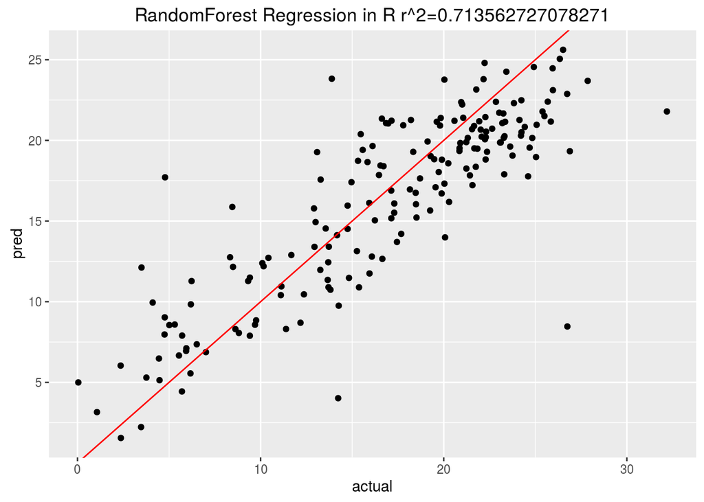

```
## Confusion matrix helada/no helada la_llave.Tmin_t
## Confusion Matrix and Statistics
##
##           Reference
## Prediction (-10,0] (0,50]
##    (-10,0]       0      0
##    (0,50]        0    181
##
##                Accuracy : 1
##                  95% CI : (0.9798, 1)
##     No Information Rate : 1
##     P-Value [Acc > NIR] : 1
##
##                   Kappa : NaN
##  Mcnemar's Test P-Value : NA
##
##             Sensitivity : NA
##             Specificity :  1
##          Pos Pred Value : NA
##          Neg Pred Value : NA
##              Prevalence :  0
##          Detection Rate :  0
##    Detection Prevalence :  0
##       Balanced Accuracy : NA
##
##        'Positive' Class : (-10,0]
##
## Confusion matrix  la_llave.Tmin_t
## Confusion Matrix and Statistics
##
##           Reference
## Prediction (-10,-5] (-5,0] (0,2] (2,5] (5,10] (10,50]
##   (-10,-5]        0      0     0     0      0       0
##   (-5,0]          0      0     0     0      0       0
##   (0,2]           0      0     0     1      0       0
##   (2,5]           0      0     2     1      1       1
##   (5,10]          0      0     0     7     15       4
##   (10,50]         0      0     0     2      6     141
##
## Overall Statistics
```

[output cut: 15 more lines]

```
## Neg Pred Value                    NA            NA     0.988889
## Prevalence                         0             0     0.011050
## Detection Rate                     0             0     0.000000
## Detection Prevalence               0             0     0.005525
## Balanced Accuracy                 NA            NA     0.497207
##                      Class: (2,5] Class: (5,10] Class: (10,50]
## Sensitivity              0.090909       0.68182         0.9658
## Specificity              0.976471       0.93082         0.7714
## Pos Pred Value           0.200000       0.57692         0.9463
## Neg Pred Value           0.943182       0.95484         0.8437
## Prevalence               0.060773       0.12155         0.8066
## Detection Rate           0.005525       0.08287         0.7790
## Detection Prevalence     0.027624       0.14365         0.8232
## Balanced Accuracy        0.533690       0.80632         0.8686
## Variable  tunuyan.Tmin_t  MSE: 9.614109  Rsquared:  0.7819678
```

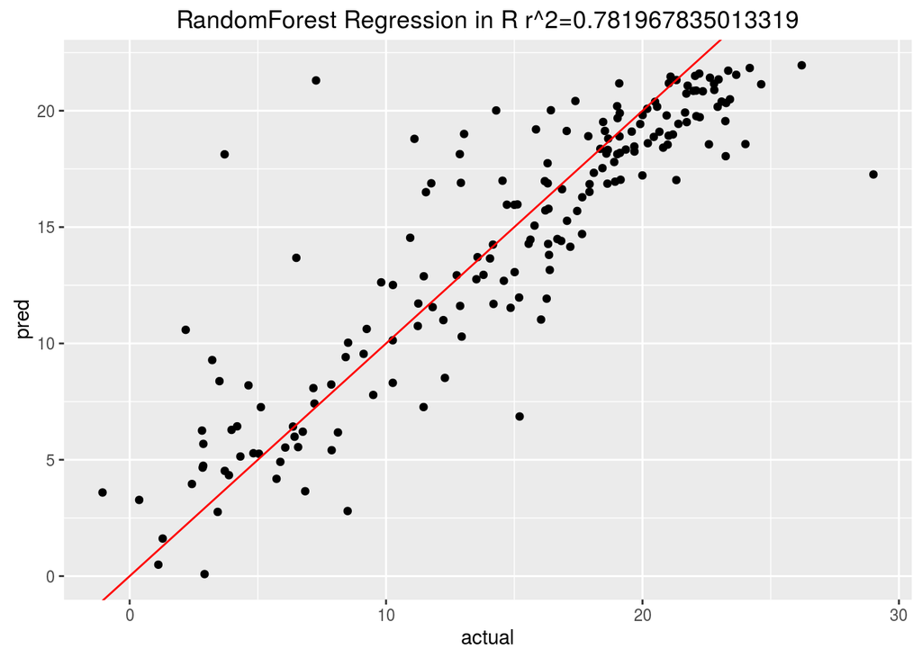

```
## Confusion matrix helada/no helada la_llave.Tmin_t
## Confusion Matrix and Statistics
##
##           Reference
## Prediction (-10,0] (0,50]
##    (-10,0]       0      0
##    (0,50]        1    180
##
##                Accuracy : 0.9945
##                  95% CI : (0.9696, 0.9999)
##     No Information Rate : 0.9945
##     P-Value [Acc > NIR] : 0.7358
##
##                   Kappa : 0
##  Mcnemar's Test P-Value : 1.0000
##
##             Sensitivity : 0.000000
##             Specificity : 1.000000
##          Pos Pred Value :      NaN
##          Neg Pred Value : 0.994475
##              Prevalence : 0.005525
##          Detection Rate : 0.000000
##    Detection Prevalence : 0.000000
##       Balanced Accuracy : 0.500000
##
##        'Positive' Class : (-10,0]
##
## Confusion matrix  tunuyan.Tmin_t
## Confusion Matrix and Statistics
##
##           Reference
## Prediction (-10,-5] (-5,0] (0,2] (2,5] (5,10] (10,50]
##   (-10,-5]        0      0     0     0      0       0
##   (-5,0]          0      0     0     0      0       0
##   (0,2]           0      0     2     1      0       0
##   (2,5]           0      1     1     6      4       0
##   (5,10]          0      0     0     9     15       4
##   (10,50]         0      0     0     2      5     131
##
## Overall Statistics
```

[output cut: 15 more lines]

```
## Neg Pred Value                    NA      0.994475      0.99438
## Prevalence                         0      0.005525      0.01657
## Detection Rate                     0      0.000000      0.01105
## Detection Prevalence               0      0.000000      0.01657
## Balanced Accuracy                 NA      0.500000      0.83052
##                      Class: (2,5] Class: (5,10] Class: (10,50]
## Sensitivity               0.33333       0.62500         0.9704
## Specificity               0.96319       0.91720         0.8478
## Pos Pred Value            0.50000       0.53571         0.9493
## Neg Pred Value            0.92899       0.94118         0.9070
## Prevalence                0.09945       0.13260         0.7459
## Detection Rate            0.03315       0.08287         0.7238
## Detection Prevalence      0.06630       0.15470         0.7624
## Balanced Accuracy         0.64826       0.77110         0.9091
## Variable  junin.Tmin_t  MSE: 8.761149  Rsquared:  0.8094467
```

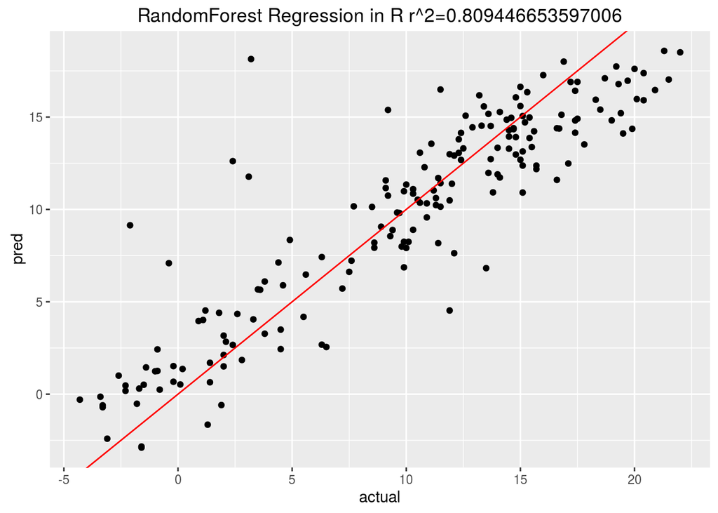

```
## Confusion matrix helada/no helada la_llave.Tmin_t
## Confusion Matrix and Statistics
##
##           Reference
## Prediction (-10,0] (0,50]
##    (-10,0]       8      2
##    (0,50]       14    157
##
##                Accuracy : 0.9116
##                  95% CI : (0.8604, 0.9486)
##     No Information Rate : 0.8785
##     P-Value [Acc > NIR] : 0.10186
##
##                   Kappa : 0.4589
##  Mcnemar's Test P-Value : 0.00596
##
##             Sensitivity : 0.36364
##             Specificity : 0.98742
##          Pos Pred Value : 0.80000
##          Neg Pred Value : 0.91813
##              Prevalence : 0.12155
##          Detection Rate : 0.04420
##    Detection Prevalence : 0.05525
##       Balanced Accuracy : 0.67553
##
##        'Positive' Class : (-10,0]
##
## Confusion matrix  junin.Tmin_t
## Confusion Matrix and Statistics
##
##           Reference
## Prediction (-10,-5] (-5,0] (0,2] (2,5] (5,10] (10,50]
##   (-10,-5]        0      0     0     0      0       0
##   (-5,0]          0      8     2     0      0       0
##   (0,2]           0     11     5     1      0       0
##   (2,5]           0      1     6     7      3       1
##   (5,10]          0      2     0     6     16       6
##   (10,50]         0      0     0     3      8      95
##
## Overall Statistics
```

[output cut: 15 more lines]

```
## Neg Pred Value                    NA       0.91813      0.95122
## Prevalence                         0       0.12155      0.07182
## Detection Rate                     0       0.04420      0.02762
## Detection Prevalence               0       0.05525      0.09392
## Balanced Accuracy                 NA       0.67553      0.65659
##                      Class: (2,5] Class: (5,10] Class: (10,50]
## Sensitivity               0.41176        0.5926         0.9314
## Specificity               0.93293        0.9091         0.8608
## Pos Pred Value            0.38889        0.5333         0.8962
## Neg Pred Value            0.93865        0.9272         0.9067
## Prevalence                0.09392        0.1492         0.5635
## Detection Rate            0.03867        0.0884         0.5249
## Detection Prevalence      0.09945        0.1657         0.5856
## Balanced Accuracy         0.67235        0.7508         0.8961
## Variable  agua_amarga.Tmin_t  MSE: 7.051851  Rsquared:  0.8059977
```

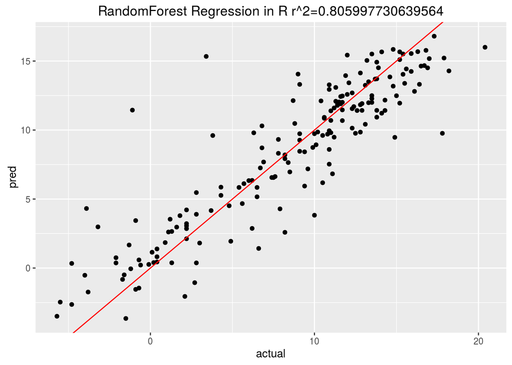

```
## Confusion matrix helada/no helada la_llave.Tmin_t
## Confusion Matrix and Statistics
##
##           Reference
## Prediction (-10,0] (0,50]
##    (-10,0]      11      2
##    (0,50]       11    157
##
##                Accuracy : 0.9282
##                  95% CI : (0.8803, 0.9612)
##     No Information Rate : 0.8785
##     P-Value [Acc > NIR] : 0.02107
##
##                   Kappa : 0.5917
##  Mcnemar's Test P-Value : 0.02650
##
##             Sensitivity : 0.50000
##             Specificity : 0.98742
##          Pos Pred Value : 0.84615
##          Neg Pred Value : 0.93452
##              Prevalence : 0.12155
##          Detection Rate : 0.06077
##    Detection Prevalence : 0.07182
##       Balanced Accuracy : 0.74371
##
##        'Positive' Class : (-10,0]
##
## Confusion matrix  agua_amarga.Tmin_t
## Confusion Matrix and Statistics
##
##           Reference
## Prediction (-10,-5] (-5,0] (0,2] (2,5] (5,10] (10,50]
##   (-10,-5]        0      0     0     0      0       0
##   (-5,0]          2      9     0     2      0       0
##   (0,2]           0      7     7     3      1       0
##   (2,5]           0      3     5     8      5       0
##   (5,10]          0      0     0     4     27      15
##   (10,50]         0      1     0     1      5      76
##
## Overall Statistics
```

[output cut: 14 more lines]

```
## Pos Pred Value                   NaN       0.69231      0.38889
## Neg Pred Value               0.98895       0.93452      0.96933
## Prevalence                   0.01105       0.11050      0.06630
## Detection Rate               0.00000       0.04972      0.03867
## Detection Prevalence         0.00000       0.07182      0.09945
## Balanced Accuracy            0.50000       0.71258      0.75912
##                      Class: (2,5] Class: (5,10] Class: (10,50]
## Sensitivity               0.44444        0.7105         0.8352
## Specificity               0.92025        0.8671         0.9222
## Pos Pred Value            0.38095        0.5870         0.9157
## Neg Pred Value            0.93750        0.9185         0.8469
## Prevalence                0.09945        0.2099         0.5028
## Detection Rate            0.04420        0.1492         0.4199
## Detection Prevalence      0.11602        0.2541         0.4586
## Balanced Accuracy         0.68234        0.7888         0.8787
```

```r
library(miscTools)
library(ggplot2)


for(i in 1:length(pred_sensores))
{
  # determinar la variable predictora
  y_label <- pred_sensores[i]
  df2 <- df
  #' renombro variable predictora por y, para facilitar formula
  colnames(df2)[which(colnames(df2)==y_label)] <- "y"
  #' quito las otras variables predictoras, ya que solo analizaré la que se encuentre en y_label
  #'
  df2 <- df2[,-which(names(df2) %in% pred_sensores)]
  colnames(df2)

  # train y test set
  until <- round(nrow(df2)*.67)
  training.set = df2[1:until, ] # This is training set to learn the parameters
  test.set = df2[until:nrow(df2), ]


  model <- randomForest(y ~ ., data = training.set, importance = TRUE )
  pred <- predict(model, test.set)
  #View(cbind(pred,test.set$y))
  mse <- mean((test.set$y - pred)^2)
  r2 <- rSquared(test.set$y, test.set$y - pred)

  cat("Variable ",pred_sensores[i]," MSE:",mse," Rsquared: ",r2)

  #' Plot R_2, valores predichos vs valores reales
  #'

  p <- ggplot(aes(x=actual, y=pred),
              data=data.frame(actual=test.set$y, pred=pred))
  p2 <- p + geom_point() +
    geom_abline(color="red") +
    ggtitle(paste("RandomForest Regression in R r^2=", r2, sep=""))

  plot(p2)

  cat("Confusion matrix helada/no helada",pred_sensores[2],"\n")

  y <- cut(test.set[,"y"], breaks = breaks.binario)
  y_pred <- cut(pred, breaks = breaks.binario)
  print(confusionMatrix(y_pred,y))

  cat("Confusion matrix ",pred_sensores[i],"\n")
  y <- cut(test.set[, "y"], breaks = my.breaks)
  y_pred <- cut(pred, breaks = my.breaks)
  print(confusionMatrix(y_pred,y))


}
```

## Oversampling: generamos más datos en el training.set mediante SMOTE

Para ello dividimos el dataset entre training y testing. En el training set aplicamos SMOTE.

genero etiquetas: 1 noche de helada y 0 no helada por cada estación, ya que tienen distintos datos de heladas

Luego evaluamos para cada una como resultó la predicción

```r
# for(j in 1:length(pred_sensores))
# {
#
#   sensor <- unlist(strsplit(pred_sensores[i],split=".",fixed = TRUE))[1]
#   vars <- v[grepl( sensor, v, fixed = TRUE)] # extraigo todas las variables relacionadas con sensor
#   #vars <- vars[-length(vars)] # quito la última variable min_t
#
# }
```

Me enfoco en el caso de la estación junin, por lo que analizaremos solo la predicción sobre la misma….

```r
var_pred <- pred_sensores[4]
Y_class <- as.factor(with(df,ifelse(df[,pred_sensores[4]] <= 0,1,0)))

hasta <- round(nrow(df)*.67)
hasta
```

```
## [1] 365
```

```r
summary(Y_class)
```

```
##   0   1
## 478  67
```

```r
summary(Y_class[hasta:length(Y_class)])
```

```
##   0   1
## 159  22
```

```r
test.set <- df[hasta:nrow(df),]
```

```r
library(unbalanced)
```

datos para entrenar

```r
data_smote <- ubBalance(df[1:(hasta-1),],Y_class[1:(hasta-1)],type = "ubSMOTE",percOver = 300, percUnder = 150)
```

para visualizar la distribución de las clases

```r
summary(data_smote$Y)
```

```
##   0   1
## 202 180
```

```r
training.set <- data_smote$X
```

Procedemos a realizar las predicciones y evaluar el error.

Aprendemos una red bayesiana usando el algoritmo hc y pasando como restricciones las white y black lists

```r
start_time <- Sys.time()
print(start_time)
```

```
## [1] "2017-10-11 13:01:18 ART"
```

```r
res = hc(training.set, whitelist=wl,blacklist = bl) # , cluster = cl) # no funciona esta funcion de cluster
end_time <- Sys.time()
end_time - start_time
```

```
## Time difference of 1.139562 secs
```

guardar modelo

```r
save(res, file= paste("hc-dacc-smote-t1-spring-",var_pred,"-",Sys.time(),".RData",sep=""))
```

Aprendizaje de parametros

```r
start_time <- Sys.time()
fitted = bn.fit(res, training.set)     # learning of parameters
end_time <- Sys.time()
end_time - start_time
```

```
## Time difference of 0.02535987 secs
```

Mostramos los parámetros para los nodos que nos interesan predecir

```r
fitted[pred_sensores]
```

```
## $las_paredes.Tmin_t
##
##   Parameters of node las_paredes.Tmin_t (Gaussian distribution)
##
## Conditional density: las_paredes.Tmin_t | las_paredes.Hmin_T_1 + las_paredes.Hmed_T_1 + las_paredes.Hmax_T_1 + las_paredes.Tmin_T_1 + las_paredes.Tmax_T_1 + las_paredes.Tmed_T_1 + la_llave.Tmax_T_1 + junin.Hmin_T_1 + agua_amarga.Hmax_T_1 + el_marcado.Tmed_T_1 + el_marcado.Hmax_T_1 + el_marcado.Hm…
## Coefficients:
##          (Intercept)  las_paredes.Hmin_T_1  las_paredes.Hmed_T_1
##          -5.22860556           -0.41440316            2.03621764
## las_paredes.Hmax_T_1  las_paredes.Tmin_T_1  las_paredes.Tmax_T_1
##          -1.57592970           -1.22317030           -1.34725647
## las_paredes.Tmed_T_1     la_llave.Tmax_T_1        junin.Hmin_T_1
##           2.22494743            0.45996525           -0.26402891
## agua_amarga.Hmax_T_1   el_marcado.Tmed_T_1   el_marcado.Hmax_T_1
##          -0.05959667            0.78937273            0.18883534
##  el_marcado.Hmin_T_1
##           0.17345833
## Standard deviation of the residuals: 2.700832
##
## $la_llave.Tmin_t
##
##   Parameters of node la_llave.Tmin_t (Gaussian distribution)
##
## Conditional density: la_llave.Tmin_t | las_paredes.Tmax_T_1 + la_llave.Hmin_T_1 + la_llave.Hmed_T_1 + la_llave.Hmax_T_1 + la_llave.Tmin_T_1 + la_llave.Tmax_T_1 + la_llave.Tmed_T_1 + tunuyan.Tmax_T_1 + junin.Tmax_T_1 + agua_amarga.Hmin_T_1 + el_marcado.Hmax_T_1 + el_marcado.Hmed_T_1 + el_marcado.H…
## Coefficients:
##          (Intercept)  las_paredes.Tmax_T_1     la_llave.Hmin_T_1
##         -10.65802790           -0.38886074            1.81067922
##    la_llave.Hmed_T_1     la_llave.Hmax_T_1     la_llave.Tmin_T_1
##          -3.93902817            2.11235745           -0.08078076
##    la_llave.Tmax_T_1     la_llave.Tmed_T_1      tunuyan.Tmax_T_1
##          -0.80822751            1.19608736            0.22772921
##       junin.Tmax_T_1  agua_amarga.Hmin_T_1   el_marcado.Hmax_T_1
##           0.69870349            0.03380389            0.17422077
##  el_marcado.Hmed_T_1   el_marcado.Hmin_T_1
##          -0.25020542            0.19158810
## Standard deviation of the residuals: 2.720467
##
## $tunuyan.Tmin_t
##
##   Parameters of node tunuyan.Tmin_t (Gaussian distribution)
##
```

[output cut: 28 more lines]

```
## $agua_amarga.Tmin_t
##
##   Parameters of node agua_amarga.Tmin_t (Gaussian distribution)
##
## Conditional density: agua_amarga.Tmin_t | junin.Tmed_T_1 + junin.Tmin_T_1 + agua_amarga.Tmax_T_1 + agua_amarga.Tmed_T_1 + agua_amarga.Tmin_T_1 + agua_amarga.Hmax_T_1 + agua_amarga.Hmed_T_1 + agua_amarga.Hmin_T_1 + el_marcado.Tmax_T_1 + el_marcado.Hmin_T_1
## Coefficients:
##          (Intercept)        junin.Tmed_T_1        junin.Tmin_T_1
##        -15.318529687           0.838265088          -0.345545253
## agua_amarga.Tmax_T_1  agua_amarga.Tmed_T_1  agua_amarga.Tmin_T_1
##         -0.007953433          -0.121883897           0.171622142
## agua_amarga.Hmax_T_1  agua_amarga.Hmed_T_1  agua_amarga.Hmin_T_1
##         -0.112679590           0.183197767          -0.057518473
##  el_marcado.Tmax_T_1   el_marcado.Hmin_T_1
##          0.375585547           0.194926871
## Standard deviation of the residuals: 2.423131
```

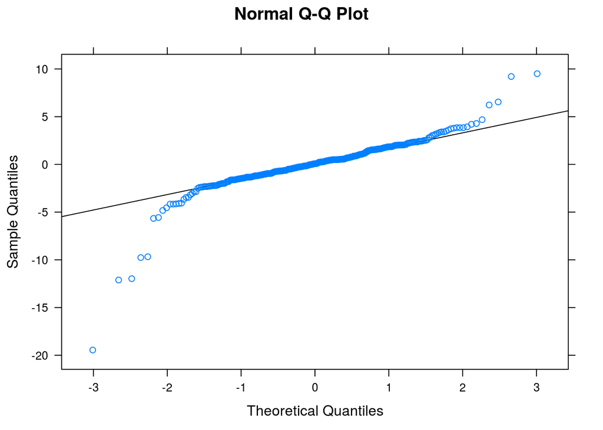

```r
bn.fit.qqplot(fitted[[ncol(df)]])
```

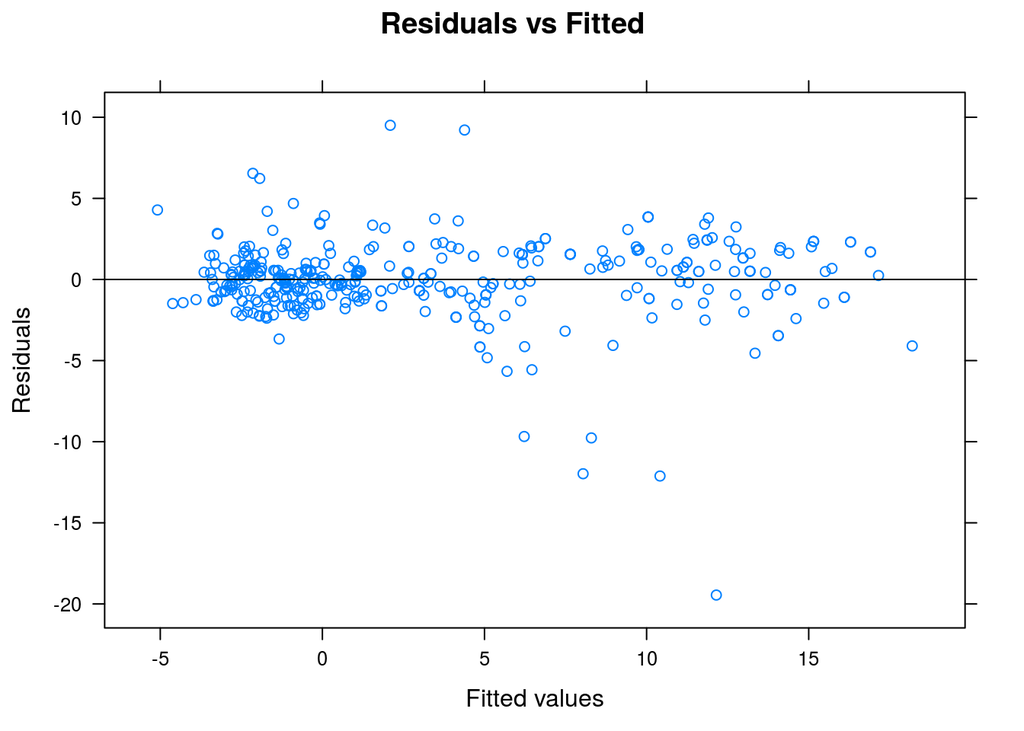

```r
bn.fit.xyplot(fitted[[ncol(df)]])
```

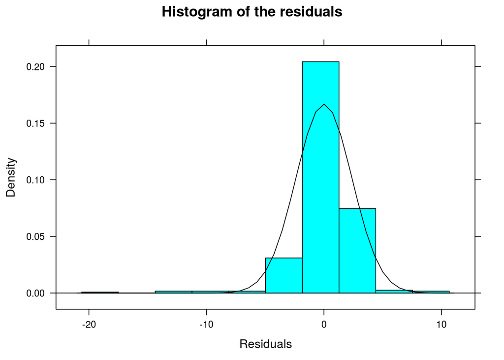

```r
bn.fit.histogram(fitted[[ncol(df)]])
```

Markov blanket de las variables de interés para predecir

```r
for(i in 1:length(pred_sensores))
{
  cat("Markov blanket of ",pred_sensores[i],"\n")
  print(mb(res,pred_sensores[i]))
}
```

```
## Markov blanket of  las_paredes.Tmin_t
##  [1] "las_paredes.Hmin_T_1" "las_paredes.Hmed_T_1" "las_paredes.Hmax_T_1"
##  [4] "las_paredes.Tmin_T_1" "las_paredes.Tmax_T_1" "las_paredes.Tmed_T_1"
##  [7] "la_llave.Hmin_T_1"    "la_llave.Hmed_T_1"    "la_llave.Hmax_T_1"
## [10] "la_llave.Tmax_T_1"    "tunuyan.Hmin_T_1"     "tunuyan.Hmax_T_1"
## [13] "junin.Hmin_T_1"       "agua_amarga.Hmax_T_1" "el_marcado.Tmax_T_1"
## [16] "el_marcado.Tmed_T_1"  "el_marcado.Hmax_T_1"  "el_marcado.Hmin_T_1"
## Markov blanket of  la_llave.Tmin_t
##  [1] "las_paredes.Tmax_T_1" "la_llave.Hmin_T_1"    "la_llave.Hmed_T_1"
##  [4] "la_llave.Hmax_T_1"    "la_llave.Tmin_T_1"    "la_llave.Tmax_T_1"
##  [7] "la_llave.Tmed_T_1"    "tunuyan.Tmax_T_1"     "junin.Tmax_T_1"
## [10] "agua_amarga.Hmin_T_1" "el_marcado.Hmax_T_1"  "el_marcado.Hmed_T_1"
## [13] "el_marcado.Hmin_T_1"
## Markov blanket of  tunuyan.Tmin_t
##  [1] "las_paredes.Tmax_T_1" "la_llave.Hmin_T_1"    "tunuyan.Hmin_T_1"
```

[output cut: 20 more lines]

Predicciones, evaluación en conjunto de testeo, caso regresión predicción temperaturas

```r
df_res <- errors_regression(var_pred, fitted, test.set, verbose = FALSE)
```

```
## Testing on  junin.Tmin_t
```

```r
df_res
```

```
##       Variable                ME             RMSE              MAE
## 1 junin.Tmin_t 0.304695815592164 3.09773471294437 2.20798504310106
##                MPE             MAPE
## 1 11.3954144305549 75.6634880780246
```

plots de R squared

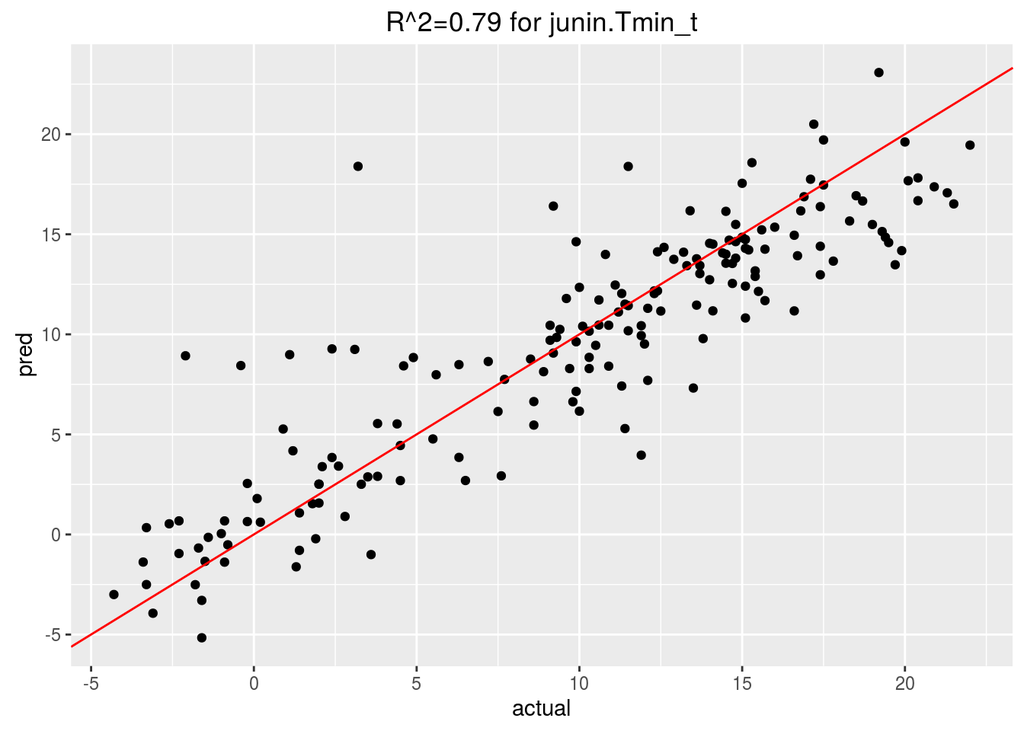

```r
r2_plots_inline(var_pred, fitted, test.set)
```

llamar confusionMatrix de caret, pasar primero “a factor of predicted classes, then a factor of classes to be used as the true results

```r
breaks.binario <- c(-10,0,50) # caso Helada y no helada
my.breaks <- c(-10,-5,0,2,5,10,50)
```

### Caso binario: helada o no helada

```r
conf_matrix_binario = conf_matrix(fitted,var_pred,test.set, breaks.binario)
```

```
## Variable  junin.Tmin_t
## Confusion Matrix and Statistics
##
##           Reference
## Prediction (-10,0] (0,50]
##    (-10,0]      13      4
##    (0,50]        9    155
##
##                Accuracy : 0.9282
##                  95% CI : (0.8803, 0.9612)
##     No Information Rate : 0.8785
##     P-Value [Acc > NIR] : 0.02107
##
##                   Kappa : 0.6272
##  Mcnemar's Test P-Value : 0.26726
##
##             Sensitivity : 0.59091
##             Specificity : 0.97484
##          Pos Pred Value : 0.76471
##          Neg Pred Value : 0.94512
##              Prevalence : 0.12155
##          Detection Rate : 0.07182
##    Detection Prevalence : 0.09392
##       Balanced Accuracy : 0.78288
##
##        'Positive' Class : (-10,0]
##
```

### Evaluación de predicción en rangos de temperaturas

```r
conf_matrix_temp = conf_matrix(fitted,var_pred,test.set, my.breaks)
```

```
## Variable  junin.Tmin_t
## Confusion Matrix and Statistics
##
##           Reference
## Prediction (-10,-5] (-5,0] (0,2] (2,5] (5,10] (10,50]
##   (-10,-5]        0      1     0     0      0       0
##   (-5,0]          0     12     3     1      0       0
##   (0,2]           0      6     5     1      0       0
##   (2,5]           0      1     3     8      4       1
##   (5,10]          0      2     2     6     17      11
##   (10,50]         0      0     0     1      6      90
##
## Overall Statistics
##
##                Accuracy : 0.7293
##                  95% CI : (0.6584, 0.7925)
##     No Information Rate : 0.5635
##     P-Value [Acc > NIR] : 3.01e-06
##
##                   Kappa : 0.5785
##  Mcnemar's Test P-Value : NA
##
## Statistics by Class:
##
##                      Class: (-10,-5] Class: (-5,0] Class: (0,2]
## Sensitivity                       NA        0.5455      0.38462
## Specificity                 0.994475        0.9748      0.95833
## Pos Pred Value                    NA        0.7500      0.41667
## Neg Pred Value                    NA        0.9394      0.95266
## Prevalence                  0.000000        0.1215      0.07182
## Detection Rate              0.000000        0.0663      0.02762
## Detection Prevalence        0.005525        0.0884      0.06630
## Balanced Accuracy                 NA        0.7601      0.67147
##                      Class: (2,5] Class: (5,10] Class: (10,50]
## Sensitivity               0.47059       0.62963         0.8824
## Specificity               0.94512       0.86364         0.9114
## Pos Pred Value            0.47059       0.44737         0.9278
## Neg Pred Value            0.94512       0.93007         0.8571
## Prevalence                0.09392       0.14917         0.5635
## Detection Rate            0.04420       0.09392         0.4972
## Detection Prevalence      0.09392       0.20994         0.5359
## Balanced Accuracy         0.70786       0.74663         0.8969
```